# Weather Discriminator Analysis

PR

February 03, 2026

```r
library(tidyverse)
library(here)
model_data <-  here("data","processed","date_metrics.rds") %>% read_rds()
```

# 1 Data trends

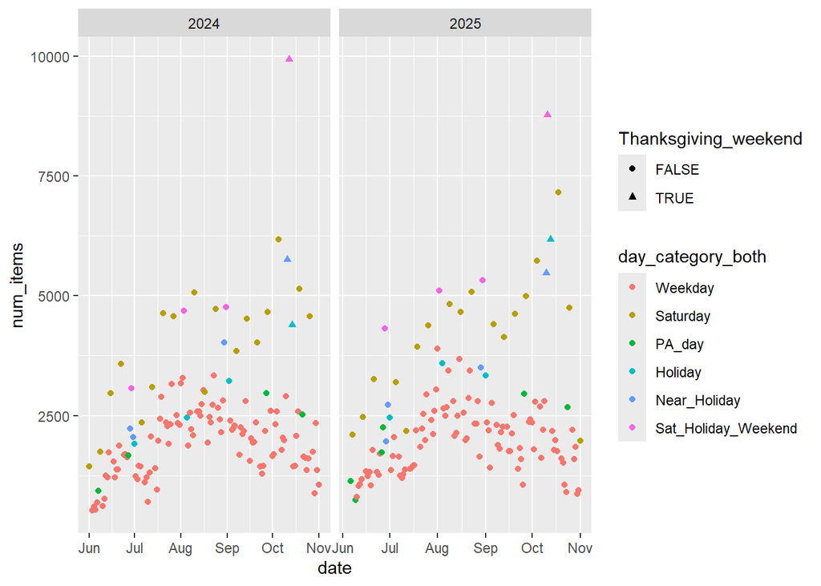

```r
model_data %>% ggplot(aes(x = date, y = num_items, color = day_category_both, shape = Thanksgiving_weekend)) +
  geom_point() +
  facet_wrap(~year, scales = "free_x")
```

# 2 Baseline Model

Best baseline model found thus far

Predicts number of items sold per day using:

- spline smoothing for season_week (int)
- day category factor
- PYO strawberry indicator
- Thanksgiving weekend indicator

I have improved this model to include interaction between day category and thanksgiving weekend.

```r
library(splines)
baseline_model <-
  lm(
    num_items ~ ns(season_week, df = 3) + day_category_both + PYO_strawberry + Thanksgiving_weekend:day_category_both,
    data = model_data
  )
summary(baseline_model)
```

```
##
## Call:
## lm(formula = num_items ~ ns(season_week, df = 3) + day_category_both +
##     PYO_strawberry + Thanksgiving_weekend:day_category_both,
##     data = model_data)
##
## Residuals:
##      Min       1Q   Median       3Q      Max
## -1826.78  -336.49   -11.66   283.60  3106.11
##
## Coefficients: (3 not defined because of singularities)
##                                                               Estimate
## (Intercept)                                                     -122.8
## ns(season_week, df = 3)1                                        1905.6
## ns(season_week, df = 3)2                                        4258.7
## ns(season_week, df = 3)3                                         260.8
## day_category_bothSaturday                                       2181.4
## day_category_bothPA_day                                          632.5
## day_category_bothHoliday                                         679.6
## day_category_bothNear_Holiday                                    962.7
## day_category_bothSat_Holiday_Weekend                            2511.7
## PYO_strawberryTRUE                                               401.1
## day_category_bothWeekday:Thanksgiving_weekendTRUE                   NA
## day_category_bothSaturday:Thanksgiving_weekendTRUE                  NA
## day_category_bothPA_day:Thanksgiving_weekendTRUE                    NA
## day_category_bothHoliday:Thanksgiving_weekendTRUE               2733.9
## day_category_bothNear_Holiday:Thanksgiving_weekendTRUE          2664.1
## day_category_bothSat_Holiday_Weekend:Thanksgiving_weekendTRUE   4847.1
##                                                               Std. Error
## (Intercept)                                                        172.2
## ns(season_week, df = 3)1                                           160.9
## ns(season_week, df = 3)2                                           388.8
## ns(season_week, df = 3)3                                           126.3
## day_category_bothSaturday                                          104.9
## day_category_bothPA_day                                            191.3
## day_category_bothHoliday                                           239.8
## day_category_bothNear_Holiday                                      240.5
## day_category_bothSat_Holiday_Weekend                               239.7
## PYO_strawberryTRUE                                                 134.8
## day_category_bothWeekday:Thanksgiving_weekendTRUE                     NA
```

[output cut: 30 more lines]

```
## day_category_bothNear_Holiday                                 ***
## day_category_bothSat_Holiday_Weekend                          ***
## PYO_strawberryTRUE                                            **
## day_category_bothWeekday:Thanksgiving_weekendTRUE
## day_category_bothSaturday:Thanksgiving_weekendTRUE
## day_category_bothPA_day:Thanksgiving_weekendTRUE
## day_category_bothHoliday:Thanksgiving_weekendTRUE             ***
## day_category_bothNear_Holiday:Thanksgiving_weekendTRUE        ***
## day_category_bothSat_Holiday_Weekend:Thanksgiving_weekendTRUE ***
## ---
## Signif. codes:  0 '***' 0.001 '**' 0.01 '*' 0.05 '.' 0.1 ' ' 1
##
## Residual standard error: 574.7 on 249 degrees of freedom
## Multiple R-squared:  0.8202, Adjusted R-squared:  0.8115
## F-statistic: 94.65 on 12 and 249 DF,  p-value: < 2.2e-16
```

This is strong for a baseline traffic proxy:

## 2.1 Residuals

Logic:

> Residuals = demand deviation after accounting for season + calendar

Red - actual number items sold  
Blue - predicted number of items

e.g.:

- in 2024, model **under-predicts** on Saturday before Thanksgiving
- in 2025, model **over-predicts** on Saturday before Thanksgiving

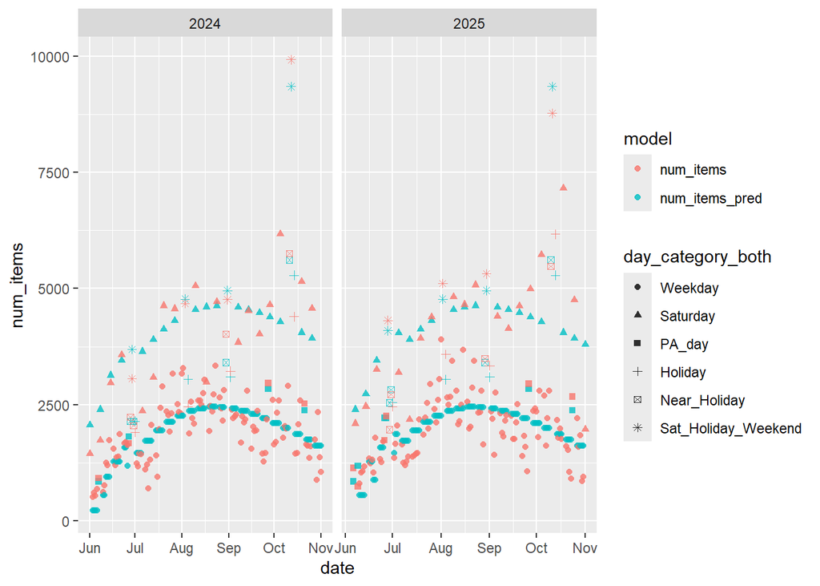

```r
model_data <- model_data %>% mutate(
  num_items_pred = predict(baseline_model, newdata = model_data),
  num_items_residual = num_items - num_items_pred
)

plot_data <-  model_data %>% pivot_longer(
  cols = c(num_items_pred, num_items),
  names_to = "model",
  values_to = "num_items"
)

plot_data %>% ggplot(aes(x = date, y = num_items, color = model, shape =  day_category_both)) +
  geom_point(alpha = 0.8) +
  facet_wrap(~year, scales = "free_x")
```

**Note:** On extreme residual days (very high positive), some may be supply-constrained rather than demand-constrained.

## 2.2 Heteroscedasticity

Interaction term (Thanksgiving:day_category_both) has balanced residuals for higher traffic days.

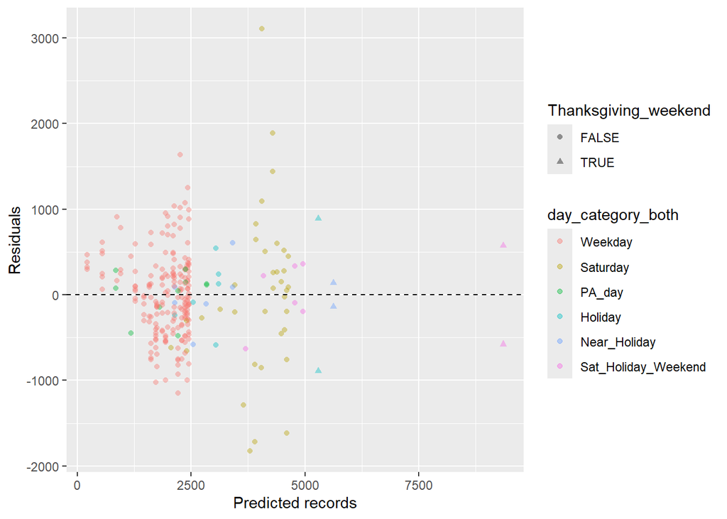

```r
ggplot(model_data, aes(num_items_pred, num_items_residual, color = day_category_both, shape = Thanksgiving_weekend)) +
  geom_point(alpha = 0.4) +
  geom_hline(yintercept = 0, linetype = "dashed") +
  labs(x = "Predicted records", y = "Residuals")
```

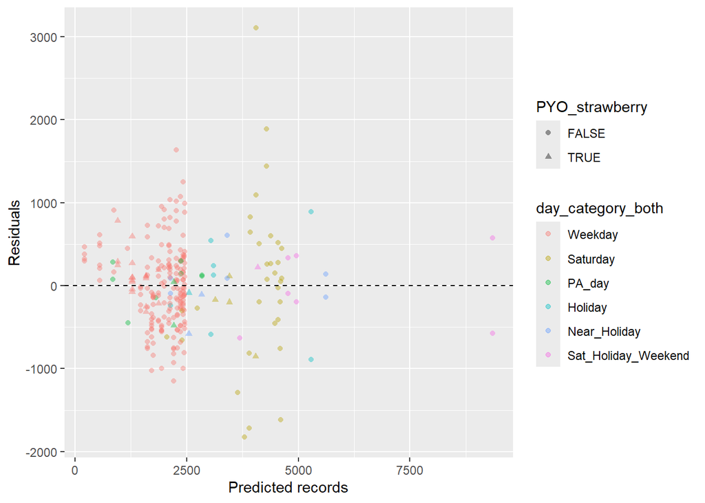

```r
ggplot(model_data, aes(num_items_pred, num_items_residual, color = day_category_both, shape = PYO_strawberry)) +
  geom_point(alpha = 0.4) +
  geom_hline(yintercept = 0, linetype = "dashed") +
  labs(x = "Predicted records", y = "Residuals")
```

## 2.3 Residuals by category

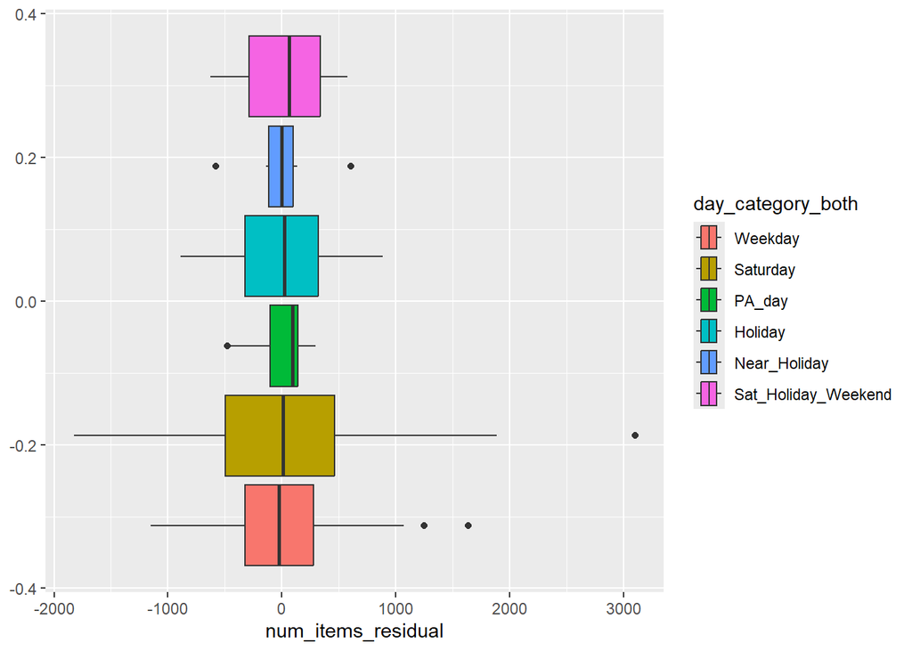

```r
model_data %>% ggplot(aes(x = num_items_residual, fill = day_category_both )) +
  geom_boxplot()
```

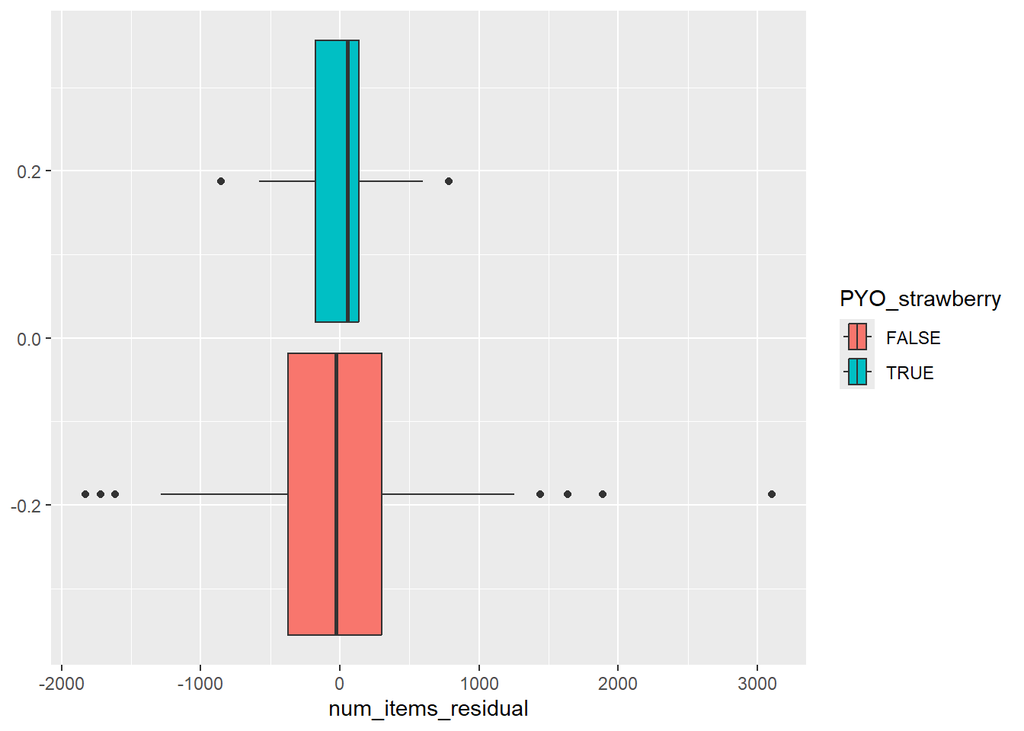

```r
model_data %>% ggplot(aes(x = num_items_residual, fill = PYO_strawberry )) +
  geom_boxplot()
```

# 3 Feature Engineering

```r
model_data <- model_data %>% mutate(
  # Ternary Label
  outcome_label = case_when(
    num_items_residual <= quantile(num_items_residual, 0.25) ~ "bad_day",
    num_items_residual >= quantile(num_items_residual, 0.75) ~ "good_day",
    TRUE ~ "neutral",
  ) %>% factor(levels = c("bad_day", "neutral", "good_day")),
  # Binary Labels
  good_day = outcome_label == "good_day",
  bad_day = outcome_label == "bad_day",
    # Weather flags
  extreme_temp_flag = (max_temp_c < 12 | max_temp_c > 32), # 53.6-89.6 degrees F
  weather_flag = (precip_flag | high_wind_flag | extreme_temp_flag),
  neutral_flag = (high_wind_flag & extreme_temp_flag),
  # Final Weather Category
  weather_category = case_when(
    precip_flag ~ "bad_weather",
    (!high_wind_flag & !extreme_temp_flag) ~ "good_weather",
    TRUE ~ "neutral_weather"
  ) %>% factor(levels = c("bad_weather","neutral_weather","good_weather"))
)
```

```r
model_data %>% count(weather_category)
```

| weather_category | n |
| --- | --- |
| bad_weather | 110 |
| neutral_weather | 22 |
| good_weather | 130 |

```r
writexl::write_xlsx(model_data,here("data","model","model_data_viewing.xlsx"))
```

# 4 Ordinal Regression

```r
# Baseline comparison
ord_fit <- MASS::polr(
  outcome_label ~ precip_flag,
  data = model_data,
  Hess = TRUE
)
summary(ord_fit)
```

```
## Call:
## MASS::polr(formula = outcome_label ~ precip_flag, data = model_data,
##     Hess = TRUE)
##
## Coefficients:
##                  Value Std. Error t value
## precip_flagTRUE -1.387     0.2563   -5.41
##
## Intercepts:
##                  Value   Std. Error t value
## bad_day|neutral  -1.7715  0.2031    -8.7241
## neutral|good_day  0.6366  0.1634     3.8964
##
## Residual Deviance: 514.7842
## AIC: 520.7842
```

```r
# add extreme temp
ord_fit <- MASS::polr(
  outcome_label ~ precip_flag + extreme_temp_flag,
  data = model_data,
  Hess = TRUE
)
summary(ord_fit)
```

```
## Call:
## MASS::polr(formula = outcome_label ~ precip_flag + extreme_temp_flag,
##     data = model_data, Hess = TRUE)
##
## Coefficients:
##                         Value Std. Error t value
## precip_flagTRUE       -1.3552     0.2572  -5.270
## extreme_temp_flagTRUE -0.7383     0.3958  -1.865
##
## Intercepts:
##                  Value   Std. Error t value
## bad_day|neutral  -1.8467  0.2085    -8.8583
## neutral|good_day  0.5858  0.1658     3.5339
##
## Residual Deviance: 511.2487
## AIC: 519.2487
```

```r
# add wind flag
ord_fit <- MASS::polr(
  outcome_label ~ precip_flag + high_wind_flag,
  data = model_data,
  Hess = TRUE
)
summary(ord_fit)
```

```
## Call:
## MASS::polr(formula = outcome_label ~ precip_flag + high_wind_flag,
##     data = model_data, Hess = TRUE)
##
## Coefficients:
##                     Value Std. Error t value
## precip_flagTRUE    -1.451     0.2637  -5.504
## high_wind_flagTRUE  0.395     0.3657   1.080
##
## Intercepts:
##                  Value   Std. Error t value
## bad_day|neutral  -1.7524  0.2038    -8.5969
## neutral|good_day  0.6637  0.1656     4.0070
##
## Residual Deviance: 513.6149
## AIC: 521.6149
```

```r
# Recommended Fit
ord_fit <- MASS::polr(
  outcome_label ~ weather_category,
  data = model_data,
  Hess = TRUE
)
summary(ord_fit)
```

```
## Call:
## MASS::polr(formula = outcome_label ~ weather_category, data = model_data,
##     Hess = TRUE)
##
## Coefficients:
##                                 Value Std. Error t value
## weather_categoryneutral_weather 1.211     0.4570   2.650
## weather_categorygood_weather    1.417     0.2644   5.358
##
## Intercepts:
##                  Value   Std. Error t value
## bad_day|neutral  -0.3852  0.1889    -2.0385
## neutral|good_day  2.0248  0.2354     8.6010
##
## Residual Deviance: 514.5686
## AIC: 522.5686
```

This gives basis for using the following indicators for categorizing weather

- rain -> bad weather
- no high winds, no extreme temps -> good weather
- high winds and/or extreme temps -> neutral weather

# 5 Write data for next step - determining order multipliers

```r
write_rds(model_data, here("data","model","model_data_2.2.rds"))
```

```r
# For next steps
model_data <- here("data","model","model_data_2.2.rds") %>% read_rds()
```

```r
# Recommended Fit
ord_fit <- MASS::polr(
  outcome_label ~ weather_category,
  data = model_data,
  Hess = TRUE
)
summary(ord_fit)
```

```
## Call:
## MASS::polr(formula = outcome_label ~ weather_category, data = model_data,
##     Hess = TRUE)
##
## Coefficients:
##                                 Value Std. Error t value
## weather_categoryneutral_weather 1.211     0.4570   2.650
## weather_categorygood_weather    1.417     0.2644   5.358
##
## Intercepts:
##                  Value   Std. Error t value
## bad_day|neutral  -0.3852  0.1889    -2.0385
## neutral|good_day  2.0248  0.2354     8.6010
##
## Residual Deviance: 514.5686
## AIC: 522.5686
```

# 6 2026 Baseline Predictions

```r
library(splines)
baseline_model <-
  lm(
    num_items ~ ns(season_week, df = 3) + day_category_both + PYO_strawberry + Thanksgiving_weekend:day_category_both,
    data = model_data
  )
summary(baseline_model)
```

```
##
## Call:
## lm(formula = num_items ~ ns(season_week, df = 3) + day_category_both +
##     PYO_strawberry + Thanksgiving_weekend:day_category_both,
##     data = model_data)
##
## Residuals:
##      Min       1Q   Median       3Q      Max
## -1826.78  -336.49   -11.66   283.60  3106.11
##
## Coefficients: (3 not defined because of singularities)
##                                                               Estimate
## (Intercept)                                                     -122.8
## ns(season_week, df = 3)1                                        1905.6
## ns(season_week, df = 3)2                                        4258.7
## ns(season_week, df = 3)3                                         260.8
## day_category_bothSaturday                                       2181.4
## day_category_bothPA_day                                          632.5
## day_category_bothHoliday                                         679.6
## day_category_bothNear_Holiday                                    962.7
## day_category_bothSat_Holiday_Weekend                            2511.7
## PYO_strawberryTRUE                                               401.1
## day_category_bothWeekday:Thanksgiving_weekendTRUE                   NA
## day_category_bothSaturday:Thanksgiving_weekendTRUE                  NA
## day_category_bothPA_day:Thanksgiving_weekendTRUE                    NA
## day_category_bothHoliday:Thanksgiving_weekendTRUE               2733.9
## day_category_bothNear_Holiday:Thanksgiving_weekendTRUE          2664.1
## day_category_bothSat_Holiday_Weekend:Thanksgiving_weekendTRUE   4847.1
##                                                               Std. Error
## (Intercept)                                                        172.2
## ns(season_week, df = 3)1                                           160.9
## ns(season_week, df = 3)2                                           388.8
## ns(season_week, df = 3)3                                           126.3
## day_category_bothSaturday                                          104.9
## day_category_bothPA_day                                            191.3
## day_category_bothHoliday                                           239.8
## day_category_bothNear_Holiday                                      240.5
## day_category_bothSat_Holiday_Weekend                               239.7
## PYO_strawberryTRUE                                                 134.8
## day_category_bothWeekday:Thanksgiving_weekendTRUE                     NA
```

[output cut: 30 more lines]

```
## day_category_bothNear_Holiday                                 ***
## day_category_bothSat_Holiday_Weekend                          ***
## PYO_strawberryTRUE                                            **
## day_category_bothWeekday:Thanksgiving_weekendTRUE
## day_category_bothSaturday:Thanksgiving_weekendTRUE
## day_category_bothPA_day:Thanksgiving_weekendTRUE
## day_category_bothHoliday:Thanksgiving_weekendTRUE             ***
## day_category_bothNear_Holiday:Thanksgiving_weekendTRUE        ***
## day_category_bothSat_Holiday_Weekend:Thanksgiving_weekendTRUE ***
## ---
## Signif. codes:  0 '***' 0.001 '**' 0.01 '*' 0.05 '.' 0.1 ' ' 1
##
## Residual standard error: 574.7 on 249 degrees of freedom
## Multiple R-squared:  0.8202, Adjusted R-squared:  0.8115
## F-statistic: 94.65 on 12 and 249 DF,  p-value: < 2.2e-16
```

```r
category_levels <- c(
        "Weekday",
        "Saturday",
        "PA_day",
        "Holiday",
        "Near_Holiday",
        "Sat_Holiday_Weekend"
)

cal = here("data","calendar","cal.rds") %>% read_rds()
pred_2026 <- cal %>%
  dplyr::select(year, date, season_week, day_category_both, PYO_strawberry, Thanksgiving_weekend) %>%
  mutate(
    day_category_both = case_when(
      day_category_both == "CLOSED" ~ NA,
      TRUE ~ day_category_both
    ) %>% factor(levels = category_levels)
  )


pred_2026 <- pred_2026 %>% mutate(
  num_items_pred = predict(baseline_model, newdata = pred_2026)
)
write_rds(pred_2026, here("data","model","pred_2026.rds"))
```

```r
# for next step
pred_2026 <- here("data","model","pred_2026.rds") %>% read_rds()
```